# Random Forest Models of Waste-Linked Diseases: Evaluation

Winsor Alpuerto, Krissa Franco & Julie Ann Lumantao

2026-10-28

This document presents the model accuracy, explainability and robustness of several random forest models. These models predict the incidence of different waste-linked diseases, which were validated using several statistics, such as RMSE, %IncMSE, RGA, RGE, and RGR.

For more information, see the [Github Repository](https://github.com/walpuerto/waste-linked-disease-modelling).

## Model Accuracy

Model accuracy was obtained using untouched testing sets. Each model had its own randomly sampled testing set from the raw data, and its predictive accuracy was evaluated using root mean square error (RMSE) and rank graduation accuracy (RGA).

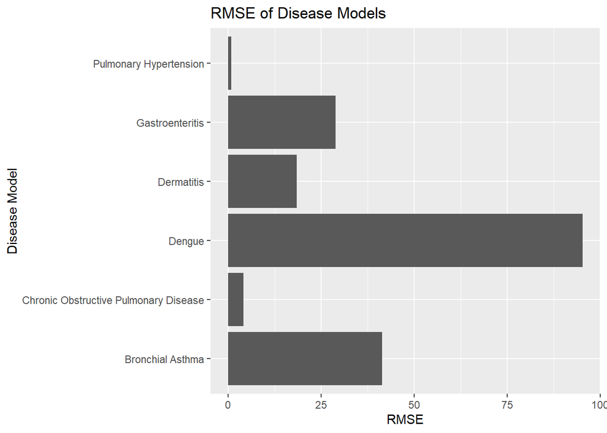

RMSE gives a general idea of how “distant” the predicted values are from the observed values. It is in the same units as the predicted variable, which in this case is incidence of disease or number of cases. For instance, on average, dengue predictions differ by about 95.24 cases from the observed values.

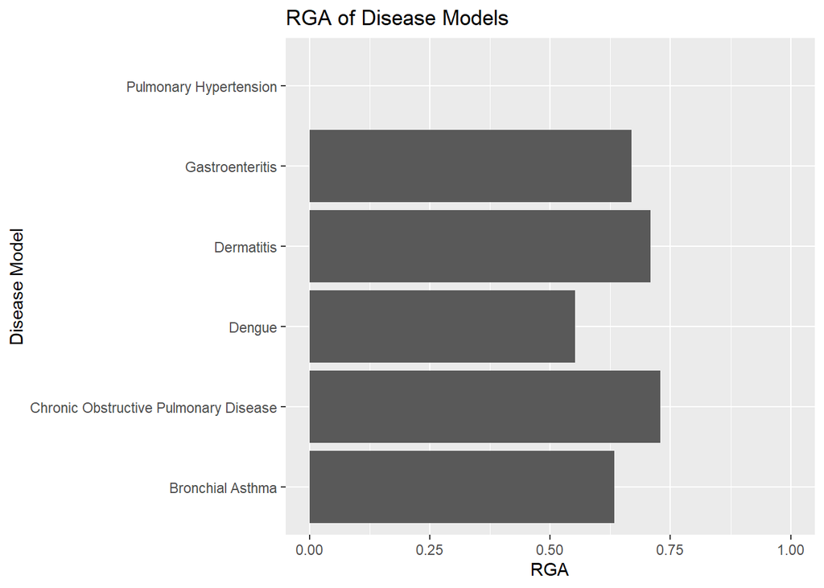

RGA measures the “concordance” of the predicted values vector to the observed values vector. A value of 1 indicates that the predictions match exactly to the observations. A value of 0 indicates that the predictions mismatch completely to the observations. A value of 0.5 indicates no correlation among the vectors. And, other values can signify a mixed interpretation.

For instance, dengue is likely uncorrelated to waste management practices because it has an RGA score of 0.55.